# Reproducible Research: Peer Assessment 1

peterkaj

3 10 2016

## Introduction

The goal of this project is to do a little bit of data analysis and wirte up a report using R markdown and knitr. The report should answer the questions in the assignment and should be completed in this single R markdown document that can be processed by knitr and be transformed into an HTML file. The data for this analysis can be downloaded from [Activity monitoring data](https://d396qusza40orc.cloudfront.net/repdata%2Fdata%2Factivity.zip) and has to be stored in the actual working directory.

## Loading and preprocessing the data

Load the activity.csv file, the necessary libraries and changes the class of the date variable to “Date”.

```r
library(ggplot2) #for plotting with ggplot
library(dplyr) #for 'select' and 'arrange'
active <- read.csv("activity.csv") #read data
active$date <- as.Date(active$date) #change class - factor to date
```

## What is mean total number of steps taken per day?

Missing Values in the dataset are ignored.

### 1.Total number of steps taken per day

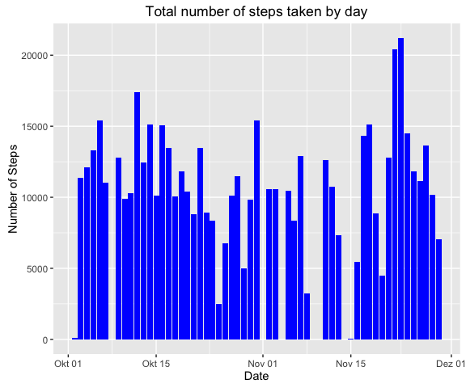

```r
daily_steps <- aggregate(steps ~ date, active, sum)
#barplot - the total number of steps taken each day
g <- ggplot(daily_steps, aes(x=date, y=steps))
g <- g + geom_bar(stat = "identity", fill="blue", na.rm=TRUE)
g + labs(title="Total number of steps taken by day", y="Number of Steps", x="Date")
```

### 2. Mean and Median of the total number of steps per day

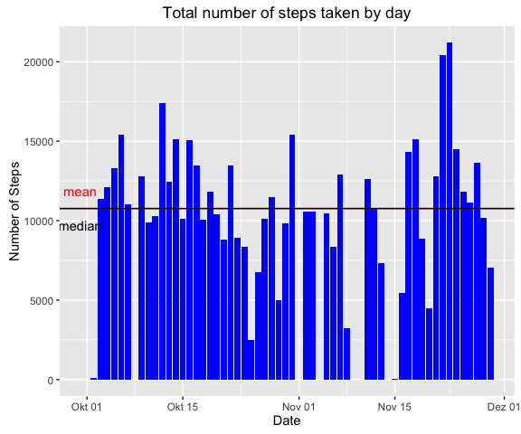

```r
mean_step <- mean(daily_steps$steps, na.rm = TRUE) # mean value of number of steps (with original data)
median_step <- median(daily_steps$steps, na.rm = TRUE) # median value of number of steps (with original data)
#barplot - the total number of steps taken each day
g <- ggplot(daily_steps, aes(x=date, y=steps))
g <- g + geom_bar(stat = "identity", fill="blue", na.rm=TRUE)
g <- g + labs(title="Total number of steps taken by day", y="Number of Steps", x="Date")
g <- g + geom_hline(yintercept = mean_step, colour="red")
g <- g + annotate("text", min(daily_steps$date)-2, mean_step*1.1, label = "mean", color="red")
g <- g + geom_hline(yintercept = median_step, colour="black")
g + annotate("text", min(daily_steps$date)-2, mean_step*0.9, label = "median", color="black")
```

The mean value of the total number of steps per day is equal to **10766.2** and the median value is equal to **10765**. Both values are presented in the plot with horizontal lines, but it is hard to differentiate the two close values.

## What is the average daily activity pattern?

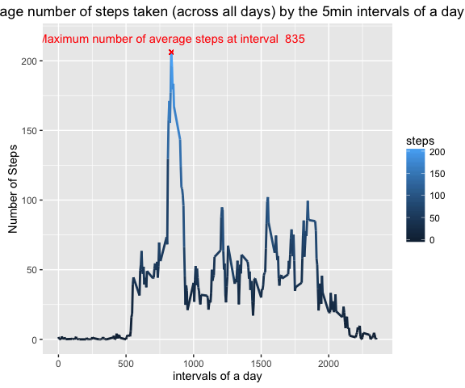

```r
avg_steps <- aggregate(steps ~ interval, active, mean) #mean value of steps across days for every interval
interval_max_step <- avg_steps$interval[which.max(avg_steps$steps)] #intervall with maximum number of steps
#lineplot
g <- ggplot(avg_steps, aes(x=interval, y=steps)) + geom_line(aes(color=steps), size=1)
g <- g + labs(title="Average number of steps taken (across all days) by the 5min intervals of a day", x="intervals of a day", y="Number of Steps")
g <- g + geom_point(aes(interval_max_step, max(avg_steps$steps)), colour="red", shape=4)
g <- g + annotate("text",interval_max_step, max(avg_steps$steps)+10, label = paste("Maximum number of average steps at interval ", interval_max_step), color="red")
g
```

The **interval 835** contains the maximum number of steps (on average across all days) and **is equal to 206.2**.

## Imputing missing values

All the missing step-values are exchanged to the mean number of steps across all days of the appropriate interval.

```r
active_na <- sum(is.na(active$steps)) #Count of NA
names(avg_steps)[2] <- "mean_steps"
active_imp <- merge(x=active, y=avg_steps, by="interval") #add mean values of steps across all days per interval
active_imp$steps[is.na(active_imp$steps)] <- active_imp$mean_steps[is.na(active_imp$steps)] # impute the values
active_imp <- select(active_imp, steps, date, interval)
active_imp <- arrange(active_imp, date, interval) # equivalent to 'active', but with imputed data
daily_steps_imp <- aggregate(steps ~ date, active_imp, sum) # equivalent to 'daily_steps' but with imputed data
mean_step_imp <- mean(daily_steps_imp$steps, na.rm = TRUE) #mean value with imputed data
median_step_imp <- median(daily_steps_imp$steps, na.rm = TRUE) #median value with imputed data
```

The new (with imputed data) mean value of the total number of steps per day is equal to** 10766.2** and the median value is equal to **10766.2**. The difference of the mean values between original data and imputed data is equal to **0** and the difference of median values is equal to **-1.19**.

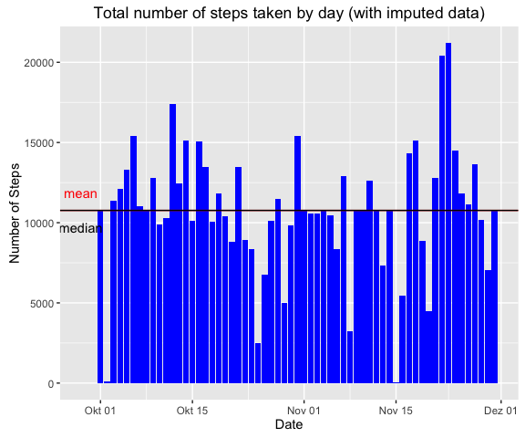

```r
#barplot - the total number of steps taken each day (with imputed data)
g <- ggplot(daily_steps_imp, aes(x=date, y=steps))
g <- g + geom_bar(stat = "identity", fill="blue", na.rm=TRUE)
g <- g + labs(title="Total number of steps taken by day (with imputed data)", y="Number of Steps", x="Date")
g <- g + geom_hline(yintercept = mean_step_imp, colour="red")
g <- g + annotate("text", min(daily_steps_imp$date)-3, mean_step_imp*1.1, label = "mean", color="red")
g <- g + geom_hline(yintercept = median_step_imp, colour="black")
g <- g + annotate("text", min(daily_steps_imp$date)-3, mean_step_imp*0.9, label = "median", color="black")
g
```

Both values (mean and median) for the imputed data are presented in the plot with horizontal lines, but it is hard to differentiate the two close values.

## Are there differences in activity patterns between weekdays and weekends?

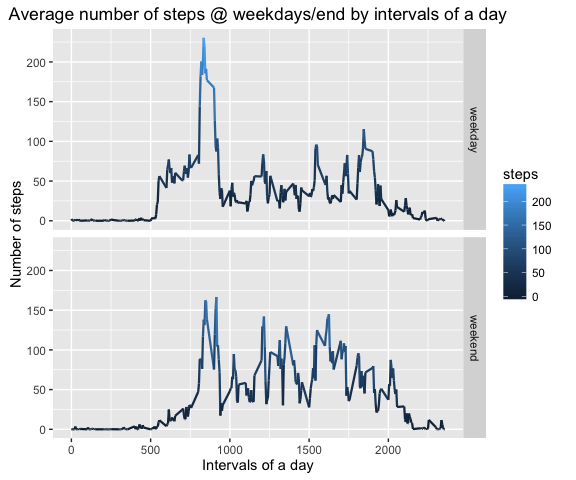

```r
active_imp$day <- "weekday" #default 'weekday'
weekend <- substr(weekdays(active_imp$date),1,1)=="S" #days which starts with 'S' (Saturday and Sunday) is weekend
active_imp$day[weekend] <- "weekend"
active_imp$day <- as.factor(active_imp$day)
avg_steps_day <- aggregate(steps ~ interval + day, active_imp, mean)
#plotting
g <- ggplot(avg_steps_day, aes(x=interval, y=steps)) + geom_line(aes(color=steps), size=0.8)
g <- g + facet_grid(day~.)
g <- g + labs(title="Average number of steps @ weekdays/end by intervals of a day", x="Intervals of a day", y="Number of steps")
g
```

End of Report